# SVM with Stochastic Gradient Descent

Stefan

April 11, 2016

## Key Pieces of the Solution

### Reading the data

```r
#' Read the data from a directory
#'
#' @param dir A directory represented as a string
#' @parem intercept A boolean, whether we want a column of 1's added to the features
#' @return The training and test set
#' @examples
#' data <- readData("/data/example", intercept = FALSE)
#' data$train$features
#' data$train$targets
#' data$test$features
#' data$test$targets
readData <- function(dir, intercept = FALSE) {
  #...
  list(
    train = list(features = features[-test.ids,], targets = targets[-test.ids]),
    test  = list(features = features[test.ids,], targets = targets[test.ids])
  )
}
```

### The fitting function

```r
#' Compute the coefficients of linear SVM
#'
#' @param train.data A list of targets and features representing the training set
#' @param test.data A list of targets and features representing the test set
#' @param lam. A double. The L2 penalty
#' @param nu. A double. The learning set size
#' @param batch.size. A int. The mini-batch size of gradient descent
#' @param init.beta. A vector. A set of coefficients to enable continued training
#' @return A list containing fitted coefficients, a predict function and train/test errors
#' @examples
#' data <- readData("/data/example", intercept = FALSE)
#' svm.fit <- fit(data$train, data$test, lam = 1.0, nu =  0.0001, batch.size = 1)
#' #support continued training
#' svm.fit <- fit(data$train, data$test, lam = 0.01, nu = 0.001, batch.size = 1, svm.fit$coef)
#' plot(svm.fit$errors.train)
#' plot(svm.fit$errors.test)
#' pred <- svm.fit$predict(data$train$features)
fit <- function(train.data, test.data, lam, nu, batch.size = 1, init.beta = NULL){
  list(coef = best.beta,
       errors.train = errors.train,
       errors.test = errors.test,
       predict = function(data){predictSVM(data, best.beta)})
}
```

### Supporting functions

```r
#' Multiply the data matrix X by the vector beta
predictScores <- function(X, beta) {}

#' Return predicted labels (-/+ 1's)
predictSVM <- function(X, beta) {}

#'The gradient of the hinge function
#' @param targets. A vector of size n
#' @param X. A matrix of dimensions n by m
#' @param beta. A vector of dimensions m
#' @return A n dimensional vector
lossGradient <- function(targets, X, beta){}

#' Computes the gradient of the loss w.r.t coefficients beta (i.e. dLoss/dbeta)
gradient <- function(loss.grad, beta, X){}

#' Compute the error rate
errorRate <- function(targets, pred.targets) {}

#' Returns a matrix where each row contains the ids in a batch
getBatch <- function(n, k) {}
```

## Experiment

### Plots of error rates over epochs

There are 3 plots (1 seeds times 3 batch sizes).

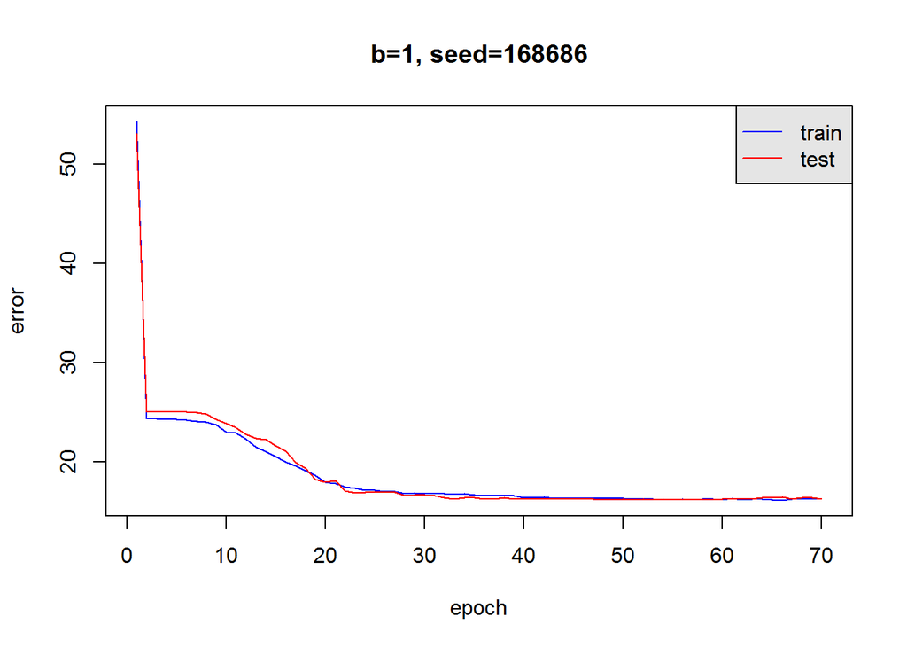

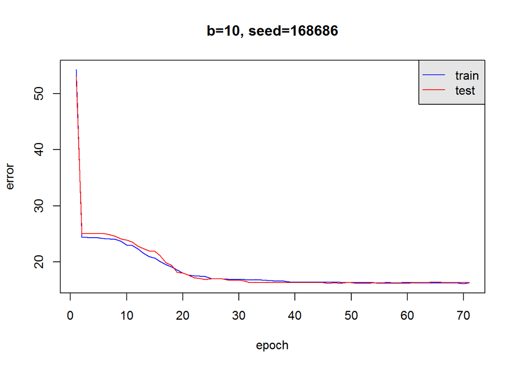

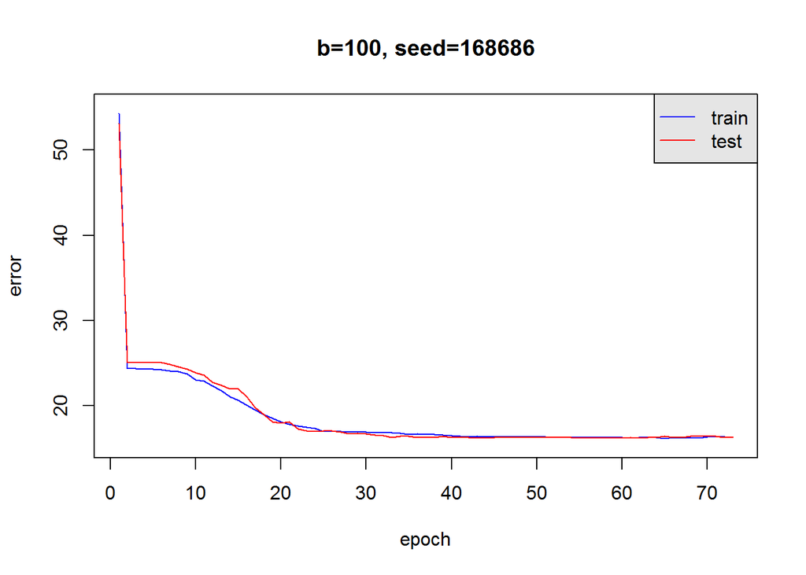

```r
results <- readRDS("D:/tmp2/results.v1.rds")

doPlots <- function(svm.fit, name){
  par(mfrow=c(1,1))
  plot(svm.fit$errors.train, type="l", col="blue", main=name,xlab="epoch", ylab="error", asp=1)
  lines(svm.fit$errors.test, col="red")
  legend("topright", c("train", "test"), col = c("blue", "red"), lty = c(1,1), merge = TRUE, bg = "gray90")
}

for(n in names(results)){
  doPlots(results[[n]]$fit, n)
}
```

### Table of statistics of experiments

Since there is randomness due to the creation of the batches and the initial solution, I could repeat the learning process with different seeds.

```r
results <- readRDS("D:/tmp2/results.v2.rds")
times <- c()
errors <- c()
epochs <- c()
for(n in names(results)){
  r <- results[[n]]
  times <- c(times, r$time[["user.self"]])
  errors <- c(errors, min(r$fit$errors.test))
  epochs <- c(epochs, length(r$fit$errors.test))
}
df <- data.frame(user_time_secs = times, errors = errors, epochs = epochs)
rownames(df) <- names(results)
print(df)
```

```
##                       user_time_secs   errors epochs
## b=1, seed=168686               22.63 16.18382     70
## b=1, seed=4458166              13.22 16.18382     41
## b=1, seed=67671117             14.65 16.28372     45
## b=1, seed=86816                26.53 16.28372     82
## b=10, seed=168686               5.26 16.18382     71
## b=10, seed=4458166              2.94 16.18382     40
## b=10, seed=67671117             3.42 16.28372     46
## b=10, seed=86816                4.43 16.48352     59
## b=100, seed=168686              3.25 16.18382     73
## b=100, seed=4458166             1.78 16.18382     41
## b=100, seed=67671117            2.14 16.28372     47
## b=100, seed=86816               2.78 16.48352     63
## b=1000, seed=168686             3.29 16.18382     75
## b=1000, seed=4458166            1.68 16.18382     43
## b=1000, seed=67671117           1.84 16.28372     49
## b=1000, seed=86816              2.00 16.48352     49
## b=5000, seed=168686             2.45 16.08392     53
## b=5000, seed=4458166            7.41 15.38462    164
## b=5000, seed=67671117           2.10 16.28372     48
## b=5000, seed=86816              1.82 16.48352     46
```

### Issues

There are interactions between $\lambda$ (L2-penalty), $\nu$ (learning step size), batch size and number of training examples.

To clear things up, first one needs to be precise whether the objective is defined as a sum over all training examples. In batch training, typically the objective is the sum over all examples + L2 penalty. In online training, the objective is given per example + L2 penalty per example. In this problem, I assume L2 penalty is for all examples. Therefore the L2 penalty needs to be adjusted by dividing by total examples. The gradient is per example when the batch size is 1. When the batch size is 10, some authors divide the sum of the gradients by 10. But when the batch size changes, one needs to adjust the learning step size.

In my code, I used:

- L2 penalty is divided by total number of examples and then multiplied by step size. Over all examples the penalty should sum to lambda.
- No division by batch size after averaging the gradient over the batch. If I divide, I need to change the learning step size.
- Learning step size is left as is suggested. It is a good choice for this problem. Since I don’t average (but sum) the gradients over the batch, the learning step need not change.

For this problem the learning process was more sensitive to setting compatible values of the above parameters with respect to each other rather than to the batch size.

### Sanity Check

As a check I ran penalized logistic regression with R library penalized and got 15.18 error rate on the test set.